# Table of Contents

```python
import numpy as np    # linear algebra
import pandas as pd   # data frames

import sklearn
from sklearn import decomposition
from sklearn import preprocessing
from sklearn.preprocessing import StandardScaler

# visualisation
import matplotlib.pyplot as plt
from matplotlib.collections import LineCollection
%matplotlib inline
import seaborn as sns
```

```python
# sépatateurs milliers = , et 2 décimales
pd.options.display.float_format = '{:,.2f}'.format
```

## Importation des données

```python
# import de clust_key_it1
pk  = pd.read_csv('data/clustkey_it1.csv', index_col=0)
pk.head(1)
```

| country | clust |
| --- | --- |
| Armenia | 2 |

```python
# import de data_it1
data  = pd.read_csv('data/data_it1.csv', index_col=0)
data.head(1)
```

| country | pop_2013 | pop_var | gdp_2013 | edb_2019 | food_kcal_cap_day | prot_g_cap_day | prot_ani_ratio | poultry_food_kg_cap_y | poultry_import_ratio | clust |
| --- | --- | --- | --- | --- | --- | --- | --- | --- | --- | --- |
| Armenia | 2.98 | 100.00 | 3,843.59 | 75.37 | 2,924.00 | 90.06 | 48.01 | 13.44 | 80.00 | 2 |

```python
# dimensions du df
print(data.shape)

#nombre d'observations
n = data.shape[0]
#nombre de variables
p = data.shape[1]
```

```
(164, 10)
```

## Instanciation et lancement des calculs

```python
# choix du nombre de composantes à calculer
n_comp = 9

# clusters auxquels appartiennent les pays
statut = [pk.loc[statut, 'clust'] for statut in data.index]

# selection des colonnes à prendre en compte dans l'ACP
data_pca = data[['pop_2013','pop_var','gdp_2013','edb_2019','food_kcal_cap_day','prot_g_cap_day',
                 'prot_ani_ratio','poultry_food_kg_cap_y','poultry_import_ratio']]

# préparation des données pour l'ACP
X = data_pca.values
names = data["clust"] # ou data.index pour avoir les intitulés
features = data.columns

# Centrage et Réduction
std_scale = preprocessing.StandardScaler().fit(X)
X_scaled = std_scale.transform(X)

# Calcul des composantes principales
acp = decomposition.PCA(svd_solver='full',n_components=n_comp)
acp.fit(X_scaled)
```

```
PCA(copy=True, iterated_power='auto', n_components=9, random_state=None,
  svd_solver='full', tol=0.0, whiten=False)
```

```python
# variance corrigée méthode 1
eigval = (n-1)/n*acp.explained_variance_
print(eigval)
```

```
[4.21991755 1.32988995 0.86339031 0.81326787 0.7285906  0.42441261
 0.33062283 0.19092943 0.09897885]
```

## Scree plot

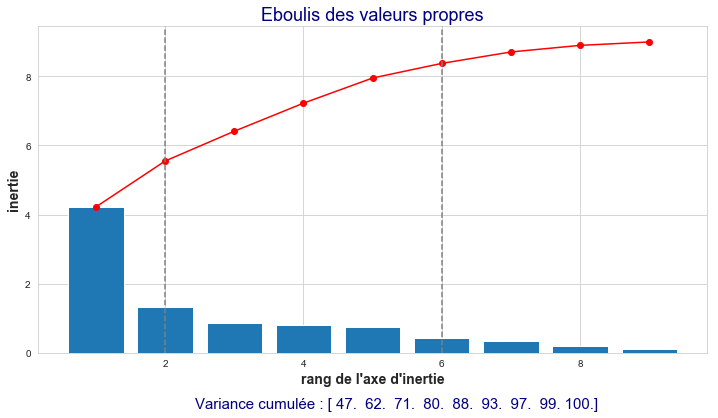

```python
#scree plot 2
sns.set_style("whitegrid")
plt.figure(figsize=(12,6))

def display_scree_plot(acp):
    scree = acp.singular_values_**2/n
    plt.bar(np.arange(len(scree))+1, scree)
    plt.plot(np.arange(len(scree))+1, scree.cumsum(),c="red",marker='o')

    plt.xlabel("rang de l'axe d'inertie",size=14, fontweight='bold')
    plt.ylabel("inertie",size=14, fontweight='bold')
    plt.title("Eboulis des valeurs propres",color='navy', size=18)
    plt.axvline(2, linestyle='dashed', color = 'grey')
    plt.axvline(6, linestyle='dashed', color = 'grey')

display_scree_plot(acp)

v=np.cumsum(acp.explained_variance_ratio_)*100
plt.text(1,-1.6, "                        Variance cumulée : %s" %np.round(v,0), color ='navy', size=15)
plt.savefig('img/P5.3_screeplot2.png', dpi=120, bbox_inches='tight')

plt.show()
plt.close()
```

**Analyse**

- Le coude apparaît dès la deuxième composante, mais cela coïncide avec les demandes du commenditaire, nous étudierons donc que le premier plan factoriel avec les composantes 1 et 2
- Le premier plan factoriel représente 62 % de la variance cumulée

## Cercle des corrélations

```python
def display_circles(pcs, n_comp, pca, axis_ranks, labels=None, label_rotation=0, lims=None):
    for d1, d2 in axis_ranks: # On affiche les 3 premiers plans factoriels, donc les 6 premières composantes
        if d2 < n_comp:

            # initialisation de la figure
            fig, ax = plt.subplots(figsize=(8,8))

            # détermination des limites du graphique
            if lims is not None :
                xmin, xmax, ymin, ymax = lims
            elif pcs.shape[1] < 30 :
                xmin, xmax, ymin, ymax = -1, 1, -1, 1
            else :
                xmin, xmax, ymin, ymax = min(pcs[d1,:]), max(pcs[d1,:]), min(pcs[d2,:]), max(pcs[d2,:])

            # affichage des flèches
            # s'il y a plus de 30 flèches, on n'affiche pas le triangle à leur extrémité
            if pcs.shape[1] < 30 :
                plt.quiver(np.zeros(pcs.shape[1]), np.zeros(pcs.shape[1]),
                   pcs[d1,:], pcs[d2,:],
                   angles='xy', scale_units='xy', scale=1, color="darkred")
                # (voir la doc : https://matplotlib.org/api/_as_gen/matplotlib.pyplot.quiver.html)
            else:
                lines = [[[0,0],[x,y]] for x,y in pcs[[d1,d2]].T]
                ax.add_collection(LineCollection(lines, axes=ax, alpha=.1, color='black'))

            # affichage des noms des variables
            if labels is not None:
                for i,(x, y) in enumerate(pcs[[d1,d2]].T):
                    if x >= xmin and x <= xmax and y >= ymin and y <= ymax :
                        plt.text(x, y, labels[i], fontsize='12', ha='left', va='center', rotation=label_rotation, color="navy", alpha=0.5)

            # affichage du cercle
            circle = plt.Circle((0,0), 1, facecolor='none', edgecolor='b')
            plt.gca().add_artist(circle)

            # définition des limites du graphique
            plt.xlim(xmin, xmax)
            plt.ylim(ymin, ymax)

            # affichage des lignes horizontales et verticales
            plt.plot([-1, 1], [0, 0], color='grey', ls='--')
            plt.plot([0, 0], [-1, 1], color='grey', ls='--')

            # nom des axes, avec le pourcentage d'inertie expliqué
            plt.xlabel('F{} ({}%)'.format(d1+1, round(100*pca.explained_variance_ratio_[d1],1)),size=13, fontweight='bold')
            plt.ylabel('F{} ({}%)'.format(d2+1, round(100*pca.explained_variance_ratio_[d2],1)),size=13, fontweight='bold')

            plt.title("Cercle des corrélations (F{} et F{})".format(d1+1, d2+1),color='navy', size=16)
            plt.show(block=False)

def get_correlation(pca, X_scaled):
    (n, p) = X_scaled.shape
    n_comp = len(pca.components_)

    eigval = pca.singular_values_**2/n
    sqrt_eigval = np.sqrt(eigval)

    covar = np.zeros((p, n_comp))
    for k in range(n_comp):
        covar[:,k] = pca.components_[k,:] * sqrt_eigval[k]

    return covar.T
```

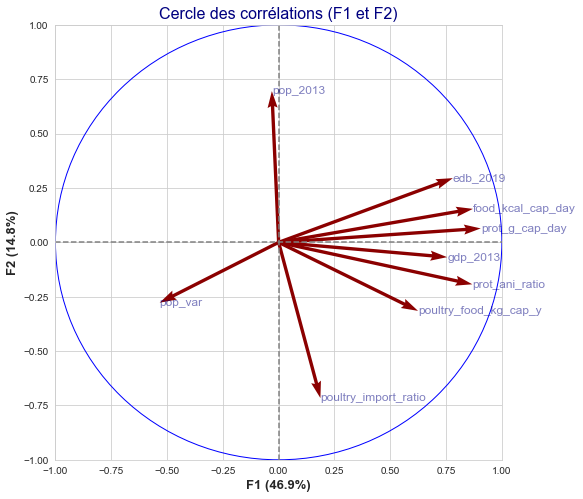

```python
# Cercle des corrélations
features = data_pca.columns
pcs = get_correlation(acp, X_scaled)
display_circles(pcs, n_comp, acp, [(0,1)], labels = np.array(features))


#plt.savefig('img/P5.3_cor_circle.png', dpi=120, bbox_inches='tight')
```

**Analyse**

- Il apparaît clairement que les variables prot_g_cap_day, prot_ani_ratio , food_kcal_cap_day , edb_2019 , gdp_2013 et, dans une moindre mesure, poultry*food* kg_cap_day sont très bien représentées sur l’axe de du premier plan
- Il faut également noter une anti-corrélation sur ce plan entre pop_var et edb_2019
- Sur le deuxième plan, nous avons une projection anti-corrélée entre pop_2013 et poultry_import_ratio
- Il faut privilégier les individus les mieux positivement représentés sur l’axe F1
- Nous devons donc chercher les individus représentés le plus à droite sur le premier plan factoriel F1

## Représentation des individus sur le plan factoriel F1-F2

```python
def display_factorial_planes(X_projected, n_comp, pca, axis_ranks, labels=None, alpha=1, illustrative_var=None):
    for d1,d2 in axis_ranks:
        if d2 < n_comp:

            # initialisation de la figure
            fig = plt.figure(figsize=(8,8))

            # affichage des points
            if illustrative_var is None:
                plt.scatter(X_projected[:, d1], X_projected[:, d2], alpha=alpha)
            else:
                illustrative_var = np.array(illustrative_var)
                for value in np.unique(illustrative_var):
                    selected = np.where(illustrative_var == value)
                    plt.scatter(X_projected[selected, d1], X_projected[selected, d2], alpha=alpha, label=value)
                plt.legend()

            # affichage des labels des points
            if labels is not None:
                for i,(x,y) in enumerate(X_projected[:,[d1,d2]]):
                    plt.text(x, y, labels[i],
                              fontsize='12', ha='center',va='center')

            # détermination des limites du graphique
            boundary = np.max(np.abs(X_projected[:, [d1,d2]])) * 1.1
            plt.xlim([-boundary,boundary])
            plt.ylim([-boundary,boundary])

            # affichage des lignes horizontales et verticales
            plt.plot([-100, 100], [0, 0], color='grey', ls='--')
            plt.plot([0, 0], [-100, 100], color='grey', ls='--')

            # nom des axes, avec le pourcentage d'inertie expliqué
            plt.xlabel('F{} ({}%)'.format(d1+1, round(100*pca.explained_variance_ratio_[d1],1)),size=13, fontweight='bold')
            plt.ylabel('F{} ({}%)'.format(d2+1, round(100*pca.explained_variance_ratio_[d2],1)),size=13, fontweight='bold')

            plt.title("Projection des individus (sur F{} et F{})".format(d1+1, d2+1),color='navy', size=16)
            plt.show(block=False)
```

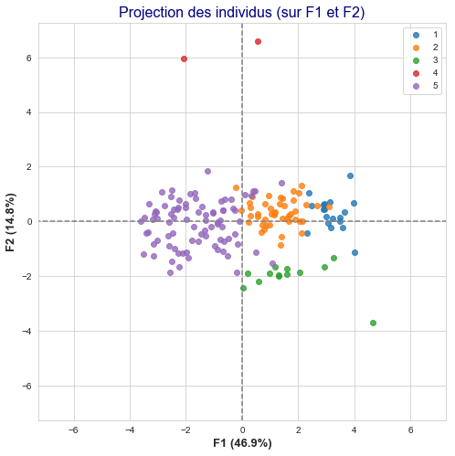

```python
# Projection des individus
X_projected = acp.transform(X_scaled)
display_factorial_planes(X_projected, n_comp, acp, [(0,1)], labels = None, illustrative_var = statut, alpha = 0.8)

plt.savefig('img/P5.3_individus.png', dpi=120, bbox_inches='tight')

plt.show()
```

**Analyse**

- Selon le cercle des corrélations, nous cherchons donc les individus qui ont les valeurs les plus élevées sur l’axe F1
- Graphiquement, on constate que cela concerne le cluster 1, ainsi qu’un ou deux des éléments des clusters 2 et 3

## Représentation des variables – Outils pour l’aide à l’interprétation

### contribution des individus à l'inertie totale

```python
#contribution des individus dans l'inertie totale
di = np.sum(X_scaled**2,axis=1)
# Création du data frame
contrib = pd.DataFrame({'ID':data.index,'d_i':di})
contrib.sort_values('d_i', axis = 0, ascending = False, inplace = True)
contrib.head(10)
```

|  | ID | d_i |
| --- | --- | --- |
| 27 | China, mainland | 84.10 |
| 64 | India | 72.15 |
| 60 | China, Hong Kong SAR | 49.86 |
| 161 | Luxembourg | 34.36 |
| 146 | United Arab Emirates | 30.24 |
| 108 | Norway | 29.32 |
| 143 | Oman | 27.64 |
| 160 | Belgium | 21.38 |
| 150 | United States of America | 21.36 |
| 80 | Kuwait | 18.93 |

```python
# qualité de représentation des individus - COS2
cos2 = pcs.T**2

ind_q = pd.DataFrame({'id':features,'COS2_1':cos2[:,0],'COS2_2':cos2[:,1]})

# tri décroissant 'COS2_1'
ind_q.sort_values('COS2_1', axis = 0, ascending = False, inplace = True)
ind_q.head()
```

|  | id | COS2_1 | COS2_2 |
| --- | --- | --- | --- |
| 5 | prot_g_cap_day | 0.82 | 0.00 |
| 4 | food_kcal_cap_day | 0.76 | 0.02 |
| 6 | prot_ani_ratio | 0.75 | 0.04 |
| 3 | edb_2019 | 0.61 | 0.09 |
| 2 | gdp_2013 | 0.57 | 0.00 |

```python
# tri décroissant 'COS2_2'
ind_q.sort_values('COS2_2', axis = 0, ascending = False, inplace = True)
ind_q.head()
```

|  | id | COS2_1 | COS2_2 |
| --- | --- | --- | --- |
| 8 | poultry_import_ratio | 0.04 | 0.51 |
| 0 | pop_2013 | 0.00 | 0.48 |
| 7 | poultry_food_kg_cap_y | 0.39 | 0.10 |
| 3 | edb_2019 | 0.61 | 0.09 |
| 1 | pop_var | 0.28 | 0.08 |

### Contribution des individus aux axes

```python
#contributions
ctr = X_projected**2

for k in range(n_comp):
     ctr[:,k] = ctr[:,k]/(n*eigval[k])

#on n'affiche que pour les deux premiers axes
ctr = pd.DataFrame({'id':data.index,'CTR_1':ctr[:,0],'CTR_2':ctr[:,1]})

# tri décroissant sur CTR_1
ctr.sort_values('CTR_1', axis = 0, ascending = False, inplace = True)
ctr.head()
```

|  | id | CTR_1 | CTR_2 |
| --- | --- | --- | --- |
| 60 | China, Hong Kong SAR | 0.03 | 0.06 |
| 161 | Luxembourg | 0.02 | 0.01 |
| 108 | Norway | 0.02 | 0.00 |
| 150 | United States of America | 0.02 | 0.01 |
| 63 | Iceland | 0.02 | 0.00 |

```python
# tri décroissant sur CTR_1
ctr.sort_values('CTR_2', axis = 0, ascending = False, inplace = True)
ctr.head()
```

|  | id | CTR_1 | CTR_2 |
| --- | --- | --- | --- |
| 27 | China, mainland | 0.00 | 0.20 |
| 64 | India | 0.01 | 0.16 |
| 60 | China, Hong Kong SAR | 0.03 | 0.06 |
| 143 | Oman | 0.00 | 0.03 |
| 123 | Saint Kitts and Nevis | 0.00 | 0.02 |

### cosinus carré des variables

```python
# cosinus carré des variables
cos2var = pcs.T**2
cos2 = pd.DataFrame({'id':features,'COS2_1':cos2var[:,0],'COS2_2':cos2var[:,1]})
cos2
```

|  | id | COS2_1 | COS2_2 |
| --- | --- | --- | --- |
| 0 | pop_2013 | 0.00 | 0.48 |
| 1 | pop_var | 0.28 | 0.08 |
| 2 | gdp_2013 | 0.57 | 0.00 |
| 3 | edb_2019 | 0.61 | 0.09 |
| 4 | food_kcal_cap_day | 0.76 | 0.02 |
| 5 | prot_g_cap_day | 0.82 | 0.00 |
| 6 | prot_ani_ratio | 0.75 | 0.04 |
| 7 | poultry_food_kg_cap_y | 0.39 | 0.10 |
| 8 | poultry_import_ratio | 0.04 | 0.51 |

```python
#contributions aux axes
ctrvar = cos2var
for k in range(n_comp):
    ctrvar[:,k] = ctrvar[:,k]/eigval[k]

#on n'affiche que pour les deux premiers axes
ctr = pd.DataFrame({'id':features,'CTR_1':ctrvar[:,0],'CTR_2':ctrvar[:,1]})
ctr
```

|  | id | CTR_1 | CTR_2 |
| --- | --- | --- | --- |
| 0 | pop_2013 | 0.00 | 0.36 |
| 1 | pop_var | 0.07 | 0.06 |
| 2 | gdp_2013 | 0.14 | 0.00 |
| 3 | edb_2019 | 0.14 | 0.07 |
| 4 | food_kcal_cap_day | 0.18 | 0.02 |
| 5 | prot_g_cap_day | 0.19 | 0.00 |
| 6 | prot_ani_ratio | 0.18 | 0.03 |
| 7 | poultry_food_kg_cap_y | 0.09 | 0.07 |
| 8 | poultry_import_ratio | 0.01 | 0.39 |

## Analyse et conclusion

```python
# Sélection des 12 pays les mieux représentés sur F1
df = pd.DataFrame(X_projected, index=data.index, columns = ['F1','F2','F3','F4','F5','F6','F7','F8','F9'])
df.drop(['F2','F3','F4','F5','F6','F7','F8','F9'], axis=1, inplace = True)

# tri décroissant 'COS2_1'
df.sort_values('F1', axis = 0, ascending = False, inplace = True)
df.head(12)
```

| country | F1 |
| --- | --- |
| China, Hong Kong SAR | 4.66 |
| Luxembourg | 4.02 |
| Norway | 3.97 |
| United States of America | 3.85 |
| Iceland | 3.63 |
| Denmark | 3.58 |
| Israel | 3.50 |
| Australia | 3.48 |
| Netherlands | 3.27 |
| Austria | 3.24 |
| Ireland | 3.15 |
| Finland | 3.13 |

```python
# left joint sur df
select = pd.merge(df, data, on='country', how = 'inner')
select.head(12)
```

| country | F1 | pop_2013 | pop_var | gdp_2013 | edb_2019 | food_kcal_cap_day | prot_g_cap_day | prot_ani_ratio | poultry_food_kg_cap_y | poultry_import_ratio | clust |
| --- | --- | --- | --- | --- | --- | --- | --- | --- | --- | --- | --- |
| China, Hong Kong SAR | 4.66 | 7.20 | 103.39 | 38,566.71 | 84.22 | 3,286.00 | 129.07 | 73.14 | 54.83 | 264.14 | 3 |
| Luxembourg | 4.02 | 0.53 | 108.83 | 113,341.24 | 69.01 | 3,540.00 | 113.64 | 63.46 | 20.75 | 90.91 | 1 |
| Norway | 3.97 | 5.04 | 105.55 | 103,110.44 | 82.95 | 3,483.00 | 110.73 | 59.58 | 21.02 | 1.89 | 1 |
| United States of America | 3.85 | 320.05 | 104.37 | 52,898.82 | 82.75 | 3,682.00 | 109.42 | 63.76 | 50.01 | 0.63 | 1 |
| Iceland | 3.63 | 0.33 | 106.80 | 47,544.16 | 79.35 | 3,381.00 | 133.06 | 72.51 | 27.27 | 11.11 | 1 |
| Denmark | 3.58 | 5.62 | 102.24 | 60,942.81 | 84.64 | 3,366.00 | 108.74 | 64.20 | 26.70 | 66.89 | 1 |
| Israel | 3.50 | 7.73 | 108.81 | 37,397.81 | 73.23 | 3,610.00 | 128.00 | 56.61 | 62.46 | 0.00 | 1 |
| Australia | 3.48 | 23.34 | 107.84 | 66,301.31 | 80.13 | 3,278.00 | 106.26 | 67.47 | 46.14 | 1.58 | 1 |
| Netherlands | 3.27 | 16.76 | 101.55 | 51,466.48 | 76.04 | 3,222.00 | 111.46 | 67.97 | 23.93 | 132.41 | 3 |
| Austria | 3.24 | 8.49 | 101.83 | 50,137.52 | 78.57 | 3,770.00 | 106.20 | 59.19 | 18.60 | 62.13 | 1 |
| Ireland | 3.15 | 4.63 | 106.32 | 51,130.08 | 78.91 | 3,602.00 | 109.91 | 58.98 | 26.15 | 61.54 | 1 |
| Finland | 3.13 | 5.43 | 102.03 | 49,659.59 | 80.35 | 3,366.00 | 117.56 | 62.12 | 19.90 | 14.04 | 1 |

### sélection des 3 pays ayant le meilleur potentiels

- Nous partons du principe que le comanditaire est européen, nous excluons Hong Kong, USA, Australia et Israel
- Luxembourg et Iceland ont moins d'un million d'habitants, cela semble insuffisant pour développer un marché
- Austria et Finland consomment moins de 20kg de volaille par an
- Poultry import ratio élevé pour Netherlands, le pays exporte 2 fois plus de volaille qu'il n'en consomme

**Les trois pays retenus sont donc : Norway, Denmark, Ireland** (ces pays sont dans le cluster 1)